# Numerical Exploration of Limits: Functions

In the previous activity, we studied limits of sequences by looking at what happens in the **tail** of a sequence.

For functions, the idea is similar, but instead of looking far out in the tail, we look at what happens to the function values when (x) gets close to a point.

In this activity, we will explore limits numerically and graphically.

We will focus on questions like:

$$ \lim_{x\to a} f(x) $$

which asks:

> What value does (f(x)) approach as (x) gets close to (a)?

## Part 1: A first example

Let's start with a familiar function:

$$ f(x)=x^2. $$

We will explore:

$$ \lim_{x\to 2} x^2. $$

This means we want to see what happens to (x^2) when (x) gets close to (2).

```python
# Values of x close to 2
x_values = [1.9, 1.99, 1.999, 2.001, 2.01, 2.1]

for x in x_values:
    print("x =", x, "   x^2 =", x**2)
```

[output not shown]

### Question 1

As $x$ gets close to $2$, what value does $x^2$ appear to approach?

Write your answer below.

**Answer:**

## Part 2: Approaching from the left and from the right

When studying limits, we often look at values of (x) that approach the point from both sides.

For $x\to 2$:

- values less than $2$ approach from the **left**
- values greater than $2$ approach from the **right**

Let's look at these separately.

```python
# Approaching 2 from the left
left_values = [1.9, 1.99, 1.999, 1.9999]

print("Approaching from the left:")
for x in left_values:
    print("x =", x, "   x^2 =", x**2)

print()

# Approaching 2 from the right
right_values = [2.1, 2.01, 2.001, 2.0001]

print("Approaching from the right:")
for x in right_values:
    print("x =", x, "   x^2 =", x**2)
```

```
Approaching from the left:
x = 1.9    x^2 = 3.61
x = 1.99    x^2 = 3.9601
x = 1.999    x^2 = 3.9960010000000006
x = 1.9999    x^2 = 3.99960001

Approaching from the right:
x = 2.1    x^2 = 4.41
x = 2.01    x^2 = 4.040099999999999
x = 2.001    x^2 = 4.004001
x = 2.0001    x^2 = 4.000400010000001
```

### Question 2

Do the values from the left and the values from the right appear to approach the same number?

**Answer:**

## Part 3: A limit can exist even if the function is not defined at the point

Now consider the function

$$ f(x)=\frac{x^2-4}{x-2}. $$

We will investigate:

$$ \lim_{x\to 2}\frac{x^2-4}{x-2}. $$

First, let's try evaluating the function at $x=2$.

```python
# Try evaluating the expression at x = 2
x = 2
# Uncomment the next line by removing the # symbol and then run the cell.
# (x**2 - 4)/(x - 2)
```

You should get an error if you try to evaluate the expression at (x=2), because the denominator is zero.

But a limit does **not** ask what happens exactly at (x=2).

It asks what happens as (x) gets close to (2).

```python
# Values of x close to 2, but not equal to 2
x_values = [1.9, 1.99, 1.999, 2.001, 2.01, 2.1]

for x in x_values:
    y = (x**2 - 4)/(x - 2)
    print("x =", x, "   f(x) =", y)
```

```
x = 1.9    f(x) = 3.8999999999999977
x = 1.99    f(x) = 3.989999999999979
x = 1.999    f(x) = 3.99899999999986
x = 2.001    f(x) = 4.00100000000014
x = 2.01    f(x) = 4.009999999999977
x = 2.1    f(x) = 4.099999999999998
```

### Question 3

Even though the function is not defined at (x=2), what value does (f(x)) appear to approach as (x\to 2)?

**Answer:**

## Part 4: Why does this happen?

The expression

$$ \frac{x^2-4}{x-2} $$

can be factored:

$$ \frac{x^2-4}{x-2} = \frac{(x-2)(x+2)}{x-2}. $$

For $x\neq 2$, we can simplify:

$$ \frac{(x-2)(x+2)}{x-2}=x+2. $$

So near $x=2$, this function behaves like

$$ x+2. $$

At $x=2$, the expression is still undefined, but nearby it behaves like $x+2$.

```python
# Compare the original expression and the simplified expression

x_values = [1.9, 1.99, 1.999, 2.001, 2.01, 2.1]

for x in x_values:
    original = (x**2 - 4)/(x - 2)
    simplified = x + 2
    print("x =", x, "   original =", original, "   simplified =", simplified)
```

```
x = 1.9    original = 3.8999999999999977    simplified = 3.9
x = 1.99    original = 3.989999999999979    simplified = 3.99
x = 1.999    original = 3.99899999999986    simplified = 3.999
x = 2.001    original = 4.00100000000014    simplified = 4.0009999999999994
x = 2.01    original = 4.009999999999977    simplified = 4.01
x = 2.1    original = 4.099999999999998    simplified = 4.1
```

### Question 4

What do you notice about the original expression and the simplified expression when (x\neq 2)?

**Answer:**

## Part 5: Graphing the function

Now let's graph the function near $x=2$.

We will avoid $x=2$, since the original expression is not defined there.

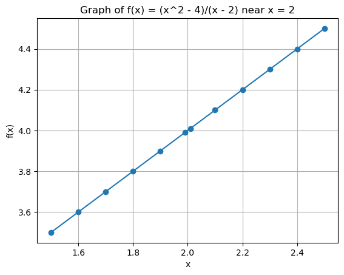

```python
import matplotlib.pyplot as plt

# Create x-values close to 2, but avoid x = 2
x_values = [1.5, 1.6, 1.7, 1.8, 1.9, 1.99, 2.01, 2.1, 2.2, 2.3, 2.4, 2.5]

y_values = []

for x in x_values:
    y = (x**2 - 4)/(x - 2)
    y_values.append(y)

plt.plot(x_values, y_values, marker="o")
plt.xlabel("x")
plt.ylabel("f(x)")
plt.title("Graph of f(x) = (x^2 - 4)/(x - 2) near x = 2")
plt.grid(True)
plt.show()
```

### Question 5

What does the graph suggest about the limit as $x\to 2$?

**Answer:**

## Part 6: One-sided limits

Sometimes, the values from the left and the right do not approach the same number.

Consider the function

$$ f(x)= \begin{cases} 1, & x<0,\\ 2, & x\geq 0. \end{cases} $$

Let's investigate what happens as $x\to 0$.

```python
# Values approaching 0 from the left
left_values = [-0.1, -0.01, -0.001, -0.0001]

print("Approaching 0 from the left:")
for x in left_values:
    y = 1
    print("x =", x, "   f(x) =", y)

print()

# Values approaching 0 from the right
right_values = [0.0001, 0.001, 0.01, 0.1]

print("Approaching 0 from the right:")
for x in right_values:
    y = 2
    print("x =", x, "   f(x) =", y)
```

```
Approaching 0 from the left:
x = -0.1    f(x) = 1
x = -0.01    f(x) = 1
x = -0.001    f(x) = 1
x = -0.0001    f(x) = 1

Approaching 0 from the right:
x = 0.0001    f(x) = 2
x = 0.001    f(x) = 2
x = 0.01    f(x) = 2
x = 0.1    f(x) = 2
```

### Question 6

What value does the function approach from the left?

What value does the function approach from the right?

Are these values the same?

**Answer:**

## Part 7: A limit that does not exist

Now consider

$$ f(x)=\frac{|x|}{x}. $$

This function behaves differently on the left and right side of $0$.

Let's investigate:

$$ \lim_{x\to 0}\frac{|x|}{x}. $$

```python
x_values = [-0.1, -0.01, -0.001, 0.001, 0.01, 0.1]

for x in x_values:
    y = abs(x)/x
    print("x =", x, "   f(x) =", y)
```

```
x = -0.1    f(x) = -1.0
x = -0.01    f(x) = -1.0
x = -0.001    f(x) = -1.0
x = 0.001    f(x) = 1.0
x = 0.01    f(x) = 1.0
x = 0.1    f(x) = 1.0
```

### Question 7

What happens as $x$ approaches $0$ from the left?

What happens as $x$ approaches $0$ from the right?

Does the limit exist?

**Answer:**

## Part 8: Visualizing $f(x)=|x|/x$

Let's graph the function near $x=0$.

Again, we avoid $x=0$, because the expression is not defined there.

[figure not shown]

```python
import matplotlib.pyplot as plt

x_values = [-1, -0.9, -0.8, -0.7, -0.6, -0.5, -0.4, -0.3, -0.2, -0.1, -0.01, -0.001,
            0.001, 0.01, 0.1, 0.2, 0.3, 0.4, 0.5, 0.6, 0.7, 0.8, 0.9, 1]

y_values = []

for x in x_values:
    y_values.append(abs(x)/x)

plt.scatter(x_values, y_values, s=50)

plt.axvline(x=0, linestyle="--")
plt.axhline(y=0, linestyle="--")

plt.xlabel("x")
plt.ylabel("f(x)")
plt.title(r"Graph of $f(x)=|x|/x$")
plt.grid(True)

plt.show()
```

### Question 8

How does the graph help explain why the limit does not exist?

**Answer:**

## Part 9: Your Turn

Investigate the following limit numerically:

$$ \lim_{x\to 3} \frac{x^2-9}{x-3}. $$

Use values of $x$ close to $3$, but not equal to $3$.

Try values from both sides of $3$.

```python
# Your Turn

# Step 1: Choose x-values close to 3.
x_values = [2.9, 2.99, 2.999, 3.001, 3.01, 3.1]

# Step 2: Complete the code below.
for x in x_values:
    # Replace the line below with the correct expression.
    y = 0
    print("x =", x, "   f(x) =", y)
```

```
x = 2.9    f(x) = 0
x = 2.99    f(x) = 0
x = 2.999    f(x) = 0
x = 3.001    f(x) = 0
x = 3.01    f(x) = 0
x = 3.1    f(x) = 0
```

### Question 9

What value does the function appear to approach as $x\to 3$?

**Answer:**

## Part 10: Reflection

Complete the following sentences.

1. To estimate a limit numerically, I can ...
2. A limit may exist even when ...
3. A limit does not exist when ...
4. Looking from the left and from the right is important because ...

## Summary

In this activity, we explored limits of functions numerically and graphically.

Important ideas:

- A limit describes what function values approach.
- The value of the function at the point is not always the same as the limit.
- A limit can exist even if the function is not defined at the point.
- For a two-sided limit to exist, the left-hand and right-hand limits must agree.
- Tables and graphs are helpful tools for building intuition about limits.